# What Makes a Great

[figure not shown]

# Package?

Joseph Rickert  
February 3, 2018

### CRAN: The Home of Hidden Treasures

12,000 + Packages

[figure not shown]

### Disenchantment with CRAN?

> “There is no benefit to having a package on CRAN”

> Richard McElreath in “Statistical Rethinking”

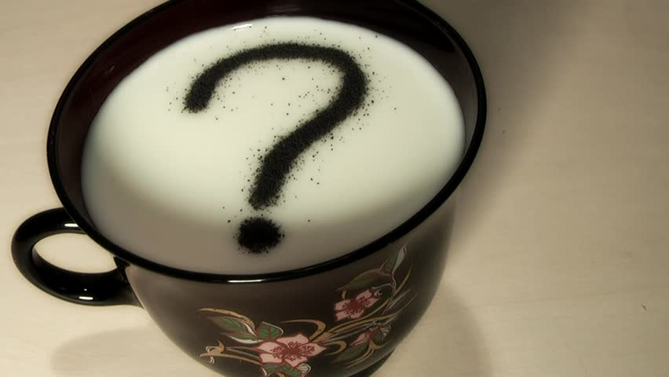

### GitHub is gaining ground

METACRAN

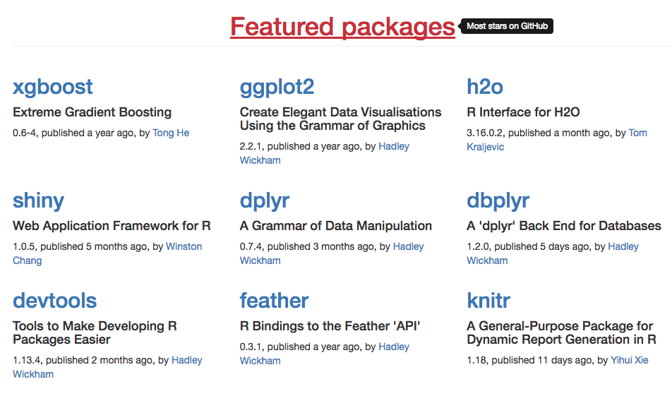

### How many CRAN Packages are valuable?

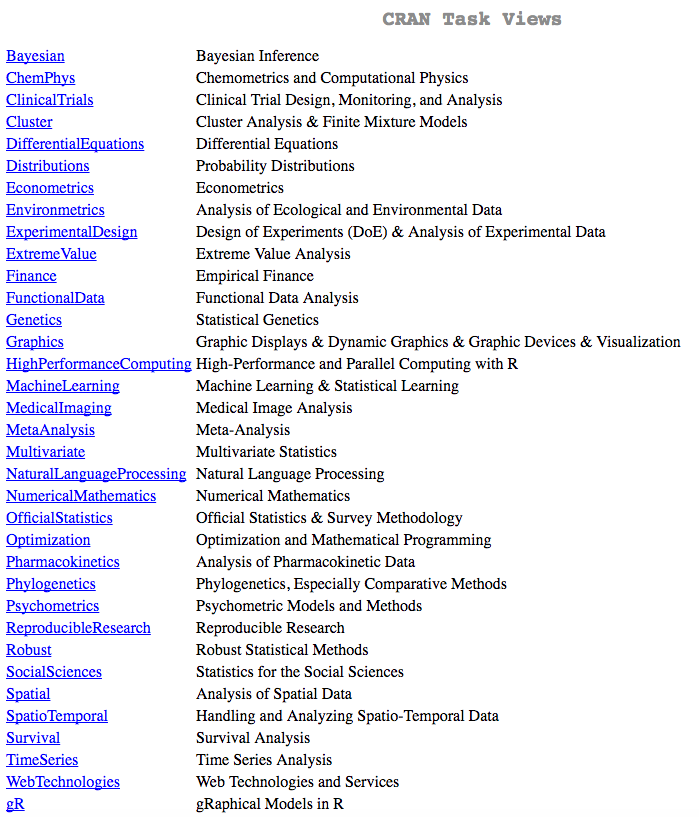

At least about ¼!

- 35 Task Views
- All curated by experts
- Containing 2,960 packages

I think most of what is on CRAN is extremely valuable!

### CRAN == Statistical Knowledge

CRAN is the worlds largest most complete repository of statistical computing knowledge.

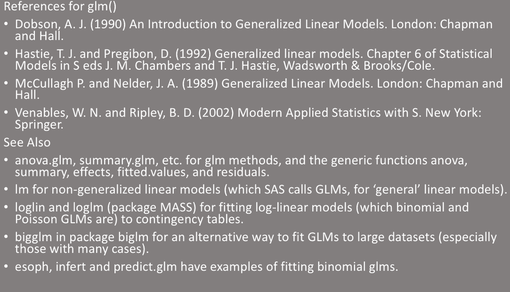

### Types of R Packages

By application domain:

- Computational Methods
- Data
- Data Science
- Machine Learning
- Science
- Statistics
- Utilities

By intended use:

- Public
- Private
  - Personal
  - Professional

### Professional Packages

e.g. [clindr](https://CRAN.R-project.org/package=clinDR)

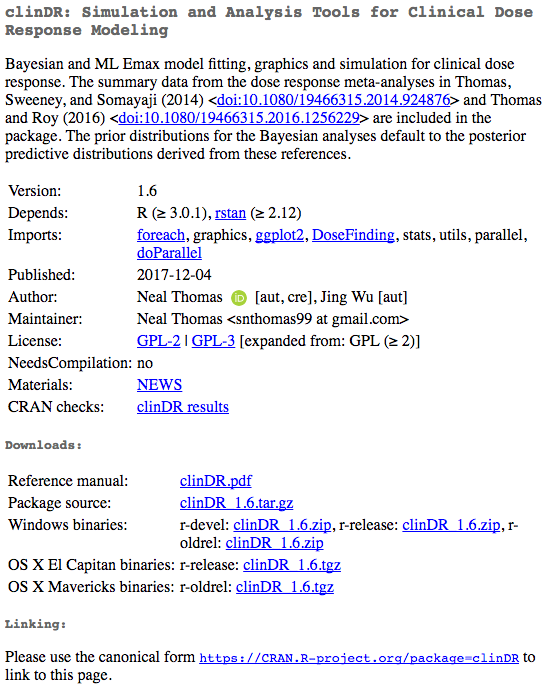

- References behind paywall
- No vignette
- No README
- Looks like quite a bit of work went into it
  - Numerous functions
  - Parallel execution

### Good R Packages:

- Do something that people other than the author might consider useful
- Offer enough functionality to make it worth remembering
- Are well documented with both:
  - Complete reference manuals that included references
  - README and NEWS files
  - Thoughtful vignettes
- Work
- Are well maintained

### The Best R Packages:

- Are well written, tested and provide helpful messages
- Have champions who actively promote, explain and teach their use
- Are likely curated by others (R Task Views)
- Used by other developers

### Great R Packages:

- Add new functionality and capabilities
- Develop new infrastructure
- Improve performance
- Change the way people think about R
- Expand the reach of R
- Do something beautiful

### My Picks for the R Package Hall of Fame

| Package | Year | Description | Author |
| --- | --- | --- | --- |
| caret | 2007 | A framework for predictive modeling | Kuhn et al. |
| bigmemory | 2008 | Matrices in memory mapped files | Kane ot al. |
| data.table | 2006 | Fast, big data queries | Dowle et al. |
| e1071 | 1999 | Machine Learning | Meyer et al. |
| dplyr | 2014 | Tidy data manipulation | Wickham et al. |
| foreach | 2009 | Parallel computing | Calaway & Weston |
| forecast | 2009 | Time series forecasting | Hyndman et al. |
| ggplot2 | 2007 | Plots and Visualizations | Wickham & Cheng |
| glmnet | 2008 | lasso, elastic net regularization | Freidman et al. |
| Hmisc | 2003 | 157 Misc data analysis & utilities | Harrell et al. |
| knitr | 2012 | Literate programming | Xie et al. |
| lme4 | 2003 | GLM mixed-effects models | Bates et al. |
| MASS | 2009 | Fundamental statistical functions | Ribley et al. |
| Matrix | 2000 | Matrix Algebra | Bates et al. |
| Rcpp | 2008 | R interface to C++ | Eddelbuettel et al. |
| rmarkdown | 2014 | Reproducible research | Allaire et al. |
| shiny | 2012 | Web apps & reactive programming | Chang et al. |
| sp | 2005 | Spatial statistics | Pebesma et al. |
| XML | 2000 | Work with XML & HTML | Temple Lang et al. |
| zoo | 2004 | Time Series | Zeileis et al. |

### Contributions of Hall of Fame Packages

- To the R Language itself: data.table, XML, bigmemory
- To Statistics: lme4, sp, glmnet, Hmisc
- To Statistical computing: foreach, Rcpp, Matrix, MASS, zoo
- To the display of information: ggplot2
- To machine learning: caret, e1071, forecast
- To reproducible research and the “science of data science”: dplyr, knitr, rmarkdown, shiny

> Wickham …making tidy data tools available …may have more impact on today’s practice of data analysis than many highly regarded theoretical statistics articles. [Donoho (20i7) *50 Years of Data Science](http://www.tandfonline.com/doi/full/10.1080/10618600.2017.1384734)

### Some Simple Package Stats

```r
pdb <- tools:::CRAN_package_db()
dim(pdb)
```

```
[1] 12096    65
```

```
       Aut  Dep  Imp  RD   RI    DepImp RDRI
mean   2.23 1.53 2.81 0.7  2.09  4.35   2.79
sd     2.69 1.58 3.87 7.37 21.25 4.06   27.2
median 1    1    1    0    0     3      0
```

### Reverse Depends and Imports Stats

RDRI quantiles

```
  0%  25%  50%  75% 100%
   0    0    0    0 1220
```

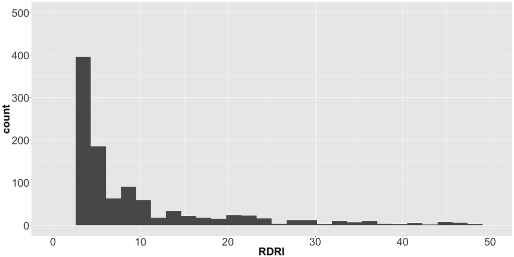

### Top 15 most integrated CRAN Packages

```
      Package Aut DepImp RDRI
1        Rcpp   7      3 1220
2        MASS   6      6 1142
4     ggplot2   3     11 1126
5       dplyr   5     12  684
6      Matrix  13      7  666
8        plyr   1      2  553
9     stringr   2      3  487
10    mvtnorm   9      3  479
11   magrittr   1      0  432
12   survival   2      7  425
14       httr   2      6  409
15   jsonlite   3      1  409
16         sp   9      8  407
17    lattice   1      6  393
19 data.table   6      2  379
```

### Collaboration

Author quantiles

```
  0%  25%  50%  75% 100%
   1    1    1    3   97
```

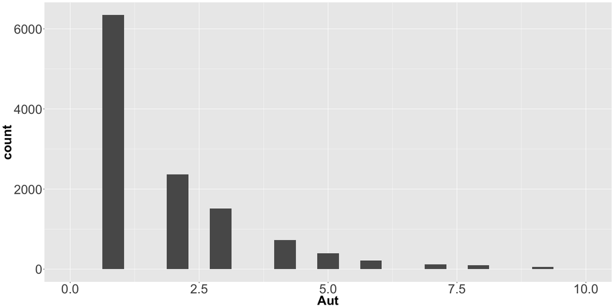

### Some Hall of Fame Stats

```
    Package Aut Dep Imp  RD   RI DepImp RDRI
       Rcpp   7   1   2 156 1064      3 1220
       MASS   6   5   1 437  706      6 1142
    ggplot2   3   1  10 284  842     11 1126
      dplyr   5   1  11  47  637     12  684
     Matrix  13   1   6 258  410      7  666
         sp   9   2   6 139  268      8  407
 data.table   6   1   1  64  315      2  379
    foreach   3   1   3  79  271      4  350
      shiny  29   2  10  41  236     12  277
        XML   1   3   0  52  169      3  221
        zoo   5   2   4  62  150      6  212
     glmnet   5   3   1  46  105      4  151
       lme4   9   4  10  47   98     14  145
      Hmisc   2   4  15  43  100     19  143
      knitr  77   1   8  10  113      9  123
      e1071   7   0   6  24   88      6  112
      caret  16   3  12   9   51     15   60
   forecast   5   1  13  22   38     14   60
  bigmemory   4   4   1  12   16      5   28
   markdown  16   1   2   3   19      3   22
```

### Alternatives to the "Great" Package

Families of intergrated packages

- [ROpenSci](https://ropensci.org/)
- [statnet](http://www.statnet.org/)
- [Tidyverse](https://www.tidyverse.org/)

[figure not shown]